# 3. El concepto de ‘Salud’

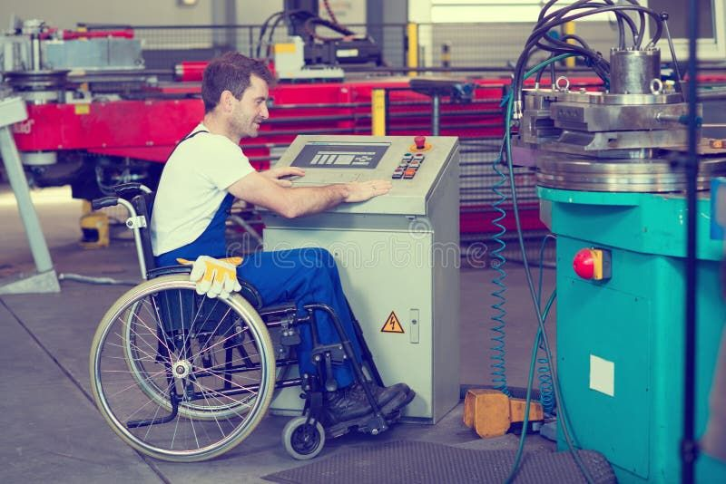

Trabajando en silla de ruedas. Fuente: es.dreamstime.com

## Actividad 1: El concepto de salud según la OMS

La OMS (Organización Mundial de la Salud), creada para promover niveles óptimos de salud para los humanos, propone una definición de salud que tiene que ver con estar “completamente” bien en varios aspectos.

Busca esta definición y escríbela en la carpeta. Luego subraya los 3 aspectos en los que se busca el bienestar.

## Actividad 2: Una opinión diferente

Alejandro Jadad, un médico y científico colombiano, nos comparte en este [video](https://www.youtube.com/watch?v=vce9cH-LnZo) un nuevo concepto de salud basado en investigaciones, experiencias y diálogo entre un grupo de especialistas. Esta idea contrasta con la definición de la OMS.

Mira el video y responde brevemente las siguientes preguntas:

1. ¿Por qué dice el autor que la OMS “se basa en una definición que nos condena a no tener salud”?
2. Completa la nueva definición de salud propuesta por el equipo coordinado por el Dr. Jadad: “La salud es la _____ para adaptarse y _____ los desafíos físicos, mentales y _____”.
3. Por que esta nueva definición permite llamarnos saludables aunque tengamos diagnósticos de enfermedades?

## Actividad 3: Conclusión

No hay un concenso total sobre la definción de “salud”. De todos modos abajo se intenta hacer una conclusión de todo lo que vimos. Copiala completanndo con las palabras que faltan.

“La definición de salud de la ____ pone el acento en el bienestar completo en distintos aspectos. La definición promovida por el Dr. Jadad se focaliza en que uno es saludable cuando es ____ de adaptarse y manejar los _____ de la vida aunque no siempre uno esté perfectamente bien. Independientemente de la definición de salud que se prefiera también aprendimos que la ‘Felicidad profunda’ está en cultivar buenas y profundas ____ con las personas.”

## Actividad 4: Eutanasia y “Villa Demencia”

El Dr. Jadad menciona que “Villa Demencia” en Holanda sería un ejemplo de una sociedad que no descarta a las personas que ya no son productivas. Sin embargo, ese mismo país fue uno de los primeros en legalizar la eutanasia, lo que puede parecer contradictorio.

**Consigna:** Investiga brevemente y luego escribe un texto corto (8–10 líneas) en el que expreses tu opinión fundamentada sobre esta aparente contradicción.

Para orientarte, puedes considerar:

- ¿Qué es la eutanasia?
- ¿Qué es “Villa Demencia” y cuál es su propósito? ¿Sigue existiendo?
- ¿Existen evidencias confiables de que, en países donde la eutanasia es legal, algunos ancianos o enfermos evitan acudir a hospitales por temor a que se les practique eutanasia sin su consentimiento o bajo presión (familiar, médica o social)?

## Actividad 5: Expresión oral

Prepara una exposición oral breve (1–2 minutos) en la que:

- Resumas tu conclusión de la Actividad 4.
- Expreses tu opinión personal de manera clara y fundamentada.

Se valorará:

- Claridad en la expresión
- Uso de ideas propias
- Capacidad de síntesis